# Ranking of Storm Events’ Effects on Population Health and Economy

2023-03-09

## Synopsis

Storm data from 1950 through November 2011 were downloaded from the NOAA Storm Database and investigated regarding which types of events cause the most human (injuries and death) and economic damage, without regard to locality or timing. It was notable that the “Event Type” (EVTYPE) contains very messy data, many alternate spellings and different names for possibly the same event types. It is unclear whether the audience needs to know about the total damage per event type, which is highly skewed by the number of events per category (Fig. 1), so results are presented both as totals and as per-event values.  
In terms of human damage, tornadoes have the highest impact in both injuries and deaths, whereas one event each which were “UNSEASONABLY WARM AND DRY” and “Heat Wave” had the highest impacts per individual event. In terms of total economic damage, FLOOD has the highest impact on property damage DROUGHT has the highest impact on crop damage. Again one event each had the highest impact on a per-event basis: “HEAVY RAIN/SEVERE WEATHER” on property damage and “EXCESSIVE WETNESS” on crop damage.

## Data Processing

Original sources of data:  
-[data](https://d396qusza40orc.cloudfront.net/repdata%2Fdata%2FStormData.csv.bz2) is a comma-separated file.  
-[Documentation](https://d396qusza40orc.cloudfront.net/repdata%2Fpeer2_doc%2Fpd01016005curr.pdf)  
-[FAQ](https://d396qusza40orc.cloudfront.net/repdata%2Fpeer2_doc%2FNCDC%20Storm%20Events-FAQ%20Page.pdf)

Download and read in the data. `read.csv()` can directly read files compressed as bz2. Running `dim()` on the table shows there are 902,297 observations of 37 columns.

```r
download.file("https://d396qusza40orc.cloudfront.net/repdata%2Fdata%2FStormData.csv.bz2",
        "storm_data.csv.bz2", mode = "wb")
stormDataRaw <- read.csv("storm_data.csv.bz2")
dim(stormDataRaw)
```

```
[1] 902297     37
```

Load libraries.

```r
library(dplyr)
```

```r
library(ggplot2)
library(forcats)
library(tidyr)
```

### Exploratory Data Analysis

**Event types: EVTYPE**

```r
x <- stormDataRaw %>% count(EVTYPE) %>% arrange(desc(n)) ## categories ranked by # of rows
```

EVTYPE has 985 distinct values. After removing rows for which there were no injuries, deaths, or economic damage (below), there were 488 categories of event type.

**Population Health: FATALITIES and INJURIES**

```r
summary(stormDataRaw$FATALITIES)
```

```
    Min.  1st Qu.   Median     Mean  3rd Qu.     Max.
  0.0000   0.0000   0.0000   0.0168   0.0000 583.0000
```

```r
summary(stormDataRaw$INJURIES)
```

```
     Min.   1st Qu.    Median      Mean   3rd Qu.      Max.
   0.0000    0.0000    0.0000    0.1557    0.0000 1700.0000
```

There are no missing data, but there are a lot of 0’s. No transformations are needed for these columns.

**Economic: PROPDMG, PROPDMGEXP, CROPDMG, CROPDMGEXP**  
From the documentation, the cost estimates will need to be transformed using 2 columns per estimate.

Cost estimates (K = thousands, M = millions, B = Billions)

```r
summary(stormDataRaw$PROPDMG)
```

```
   Min. 1st Qu.  Median    Mean 3rd Qu.    Max.
   0.00    0.00    0.00   12.06    0.50 5000.00
```

```r
summary(as.factor(stormDataRaw$PROPDMGEXP))
```

```
            -      ?      +      0      1      2      3      4      5      6
465934      1      8      5    216     25     13      4      4     28      4
     7      8      B      h      H      K      m      M
     5      1     40      1      6 424665      7  11330
```

```r
summary(stormDataRaw$CROPDMG)
```

```
   Min. 1st Qu.  Median    Mean 3rd Qu.    Max.
  0.000   0.000   0.000   1.527   0.000 990.000
```

```r
summary(as.factor(stormDataRaw$CROPDMGEXP))
```

```
            ?      0      2      B      k      K      m      M
618413      7     19      1      9     21 281832      1   1994
```

The “EXP” columns have a lot of messy data. I will convert what’s obvious (lower case to upper case for k and m will be handled when converting to total dollars), and the remainder will be ignored. “H/h” may refer to hundreds, but there are only 7 entries, and are not likely to contribute meaningfully to the most costly events.

### Transformations

```r
stormData <- stormDataRaw %>%
     filter(FATALITIES > 0 | INJURIES > 0 | CROPDMG > 0 | PROPDMG >0) %>%
     mutate(property = case_when(
          PROPDMGEXP == 'K' ~ PROPDMG * 1000,
          PROPDMGEXP == 'k' ~ PROPDMG * 1000,
          PROPDMGEXP == 'M' ~ PROPDMG * 1000000,
          PROPDMGEXP == 'm' ~ PROPDMG * 1000000,
          PROPDMGEXP == 'B' ~ PROPDMG * 1000000000,
          TRUE ~ PROPDMG
     )) %>%
     mutate(crop = case_when(
          CROPDMGEXP == 'K' ~ CROPDMG * 1000,
          CROPDMGEXP == 'k' ~ CROPDMG * 1000,
          CROPDMGEXP == 'M' ~ CROPDMG * 1000000,
          CROPDMGEXP == 'm' ~ CROPDMG * 1000000,
          CROPDMGEXP == 'B' ~ CROPDMG * 1000000000,
          TRUE ~ CROPDMG
     ))
summary(stormData$property)
```

```
     Min.   1st Qu.    Median      Mean   3rd Qu.      Max.
0.000e+00 2.000e+03 1.000e+04 1.678e+06 3.500e+04 1.150e+11
```

```r
summary(stormData$crop)
```

```
     Min.   1st Qu.    Median      Mean   3rd Qu.      Max.
0.000e+00 0.000e+00 0.000e+00 1.928e+05 0.000e+00 5.000e+09
```

Make a table which summarizes by EVTYPE, including total bodily and economic damages, as well as each of those values averaged per event by event type. Without this transformation, large numbers in the data could be confounded by large numbers of events.  
Transform EVDATA into a factor with levels that scale with the number of events of each type.  
In addition, add columns to scale the values as percent of total, allowing all events to be plotted on the same graph. Then melt the scaled data into a longer table.  
Finally, filter the rows to contain only those event types which contribute to at least 1% of their respective damage.

```r
groupedStormData <- stormData %>% group_by(EVTYPE) %>%
     summarize(n=n(), FatPerEvent = mean(FATALITIES), Fatalities = sum(FATALITIES),
              InjPerEvent = mean(INJURIES), raw.injuries = sum(INJURIES),
              PropDamPerEvent = mean(property), PropertyDamage = sum(property),
              CropDamPerEvent = mean(crop), CropDamage = sum(crop)) %>%
     ## scale all columns to % of total
     mutate(Deaths.Per.Event = FatPerEvent/sum(FatPerEvent),
          Deaths = Fatalities/sum(Fatalities)    ,
          Injuries.Per.Event = InjPerEvent/sum(InjPerEvent),
          Injuries = raw.injuries/sum(raw.injuries),
          Property.Damage.per.event = PropDamPerEvent/sum(PropDamPerEvent),
          Property.Damage = PropertyDamage/sum(PropertyDamage),
          Crop.Damage.per.Event = CropDamPerEvent/sum(CropDamPerEvent),
          Crop.Damage = CropDamage/sum(CropDamage)
          ) %>%
     arrange(n)

## make EVTYPE a factor with levels relative to the current sort by frequency
groupedStormData$EVTYPE <- factor(groupedStormData$EVTYPE, levels = groupedStormData$EVTYPE)


## transform table to long so multiple categories can be in the same bar
## Make 2 tables one for human damage (injuries, fatalities) and other economic
longHumanStormData <- groupedStormData %>% pivot_longer(
     cols = c("Deaths.Per.Event","Deaths","Injuries.Per.Event","Injuries"),
     names_to = "Damage.Type", values_to = "value")
longHumanStormData$Damage.Type <- as.factor(longHumanStormData$Damage.Type)
longEconStormData <- groupedStormData %>% pivot_longer(
     cols = c("Property.Damage.per.event","Crop.Damage.per.Event","Property.Damage","Crop.Damage"),
     names_to = "Damage.Type", values_to = "value")
longEconStormData$Damage.Type <- as.factor(longEconStormData$Damage.Type)
## limit data to only events with damage that accounts for 1% of category
longHumanStormData <- longHumanStormData %>% filter(value>0.01)
longEconStormData <- longEconStormData %>% filter(value>0.01)

str(groupedStormData$EVTYPE)
```

```
 Factor w/ 488 levels "   HIGH SURF ADVISORY",..: 1 2 3 4 5 6 7 8 9 10 ...
```

```r
str(longHumanStormData$EVTYPE)
```

```
 Factor w/ 488 levels "   HIGH SURF ADVISORY",..: 7 10 18 20 30 55 72 72 73 98 ...
```

```r
str(longEconStormData$EVTYPE)
```

```
 Factor w/ 488 levels "   HIGH SURF ADVISORY",..: 19 31 33 78 109 109 207 252 254 285 ...
```

## Results

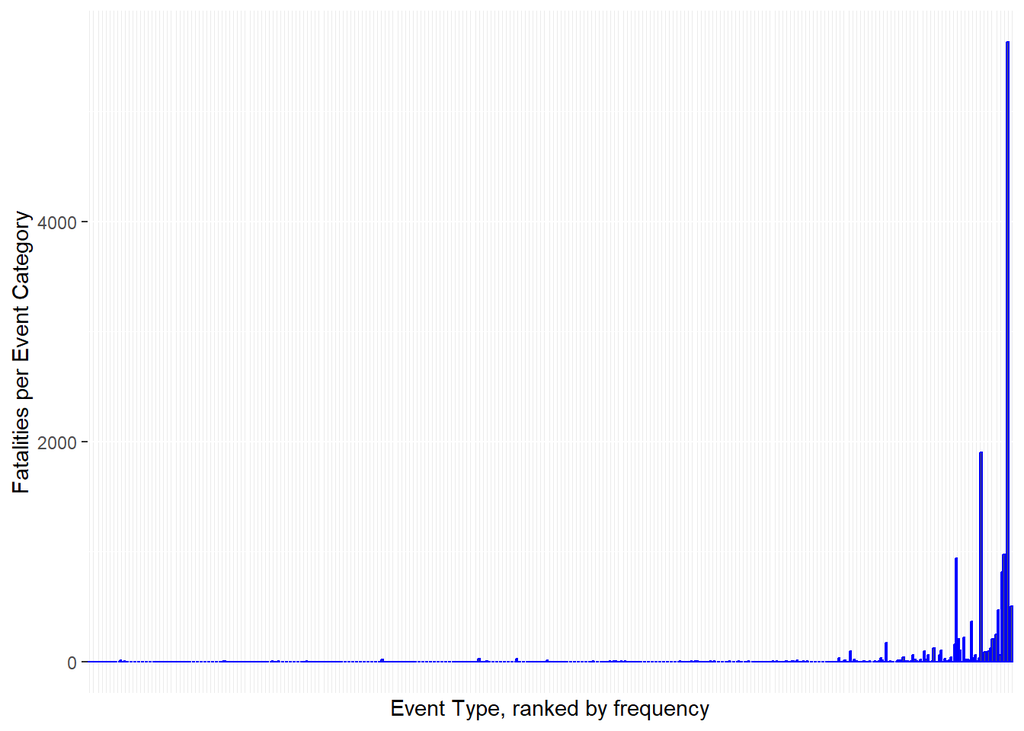

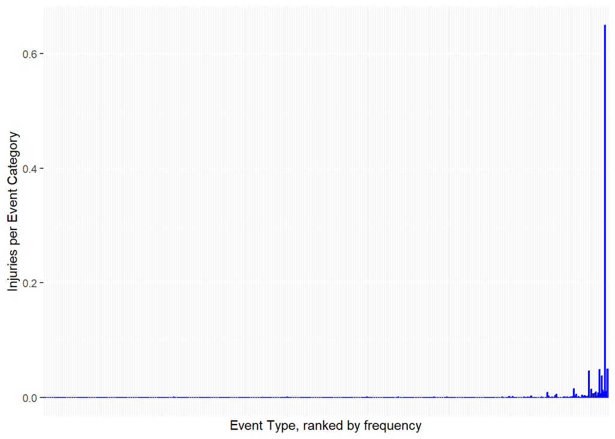

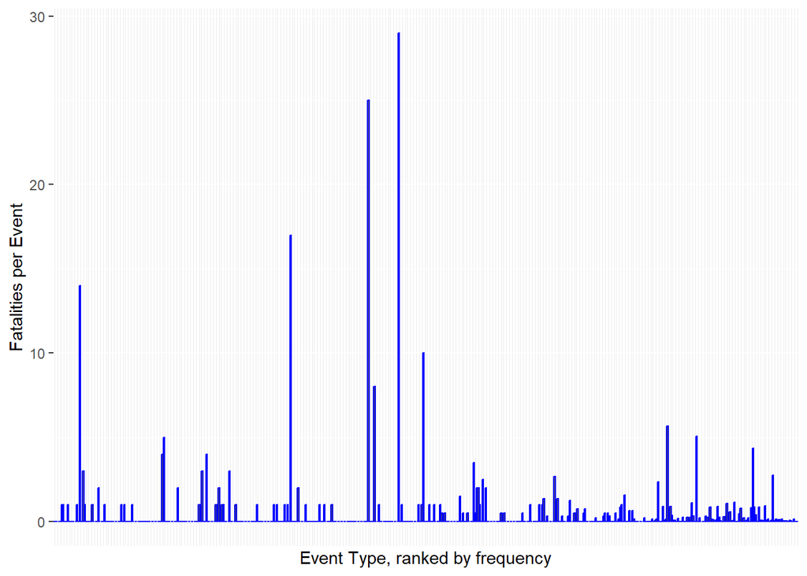

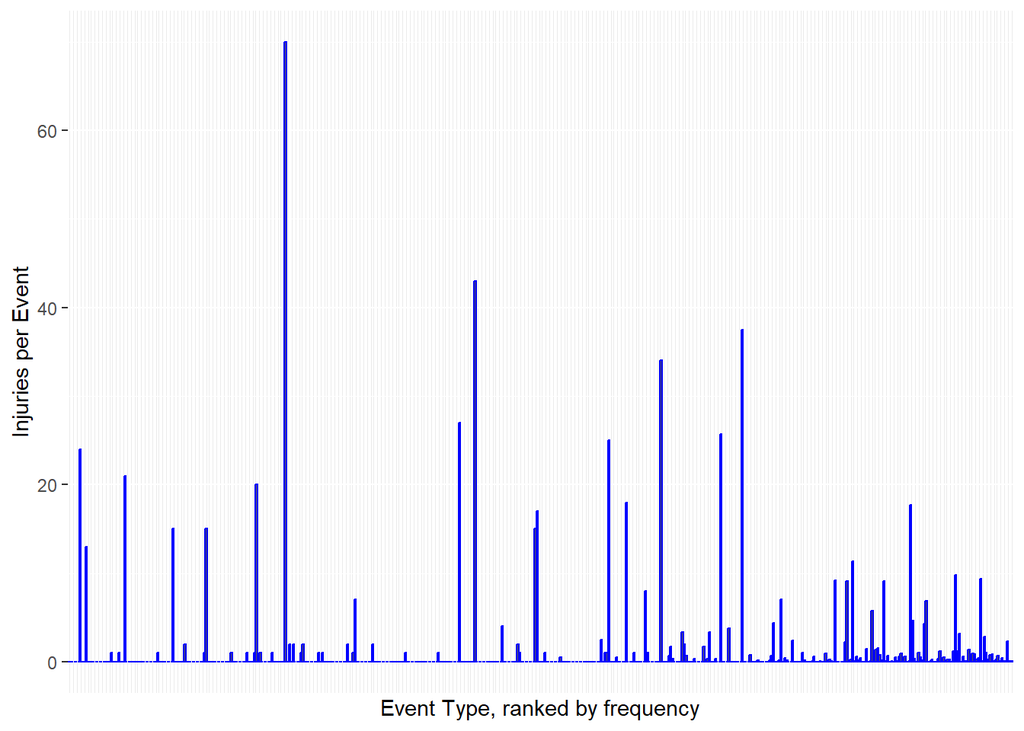

```r
# 1 Total Fatalities
p <- ggplot(groupedStormData, aes(EVTYPE, y=Fatalities))
p + geom_col(color = "blue") + labs(y = "Fatalities per Event Category",
         x = "Event Type, ranked by frequency") +
     scale_x_discrete(guide = NULL)
# 2 Total Injuries
q <- ggplot(groupedStormData, aes(EVTYPE, y=Injuries))
q + geom_col(color = "blue") + labs(y = "Injuries per Event Category",
         x = "Event Type, ranked by frequency") +
     scale_x_discrete(guide = NULL)
# 3 Fatalities per Event
r <- ggplot(groupedStormData, aes(EVTYPE, y=FatPerEvent))
r + geom_col(color = "blue") + labs(y = "Fatalities per Event",
         x = "Event Type, ranked by frequency") +
     scale_x_discrete(guide = NULL)
# 4 Injuries per Event
s <- ggplot(groupedStormData, aes(EVTYPE, y=InjPerEvent))
s + geom_col(color = "blue") + labs(y = "Injuries per Event",
         x = "Event Type, ranked by frequency") +
     scale_x_discrete(guide = NULL)
```

**Figure 1 (above). Exploratory Analysis of Storm Effects on Human Health**

It’s unclear whether the audience wants to know the total damage that’s been done by an event type or the predicted damage for a single event. I have plotted both on the following figures. To reduce noise from so many event categories, for all types of damage, I included only events that represent at least 1% of the damage for that category.

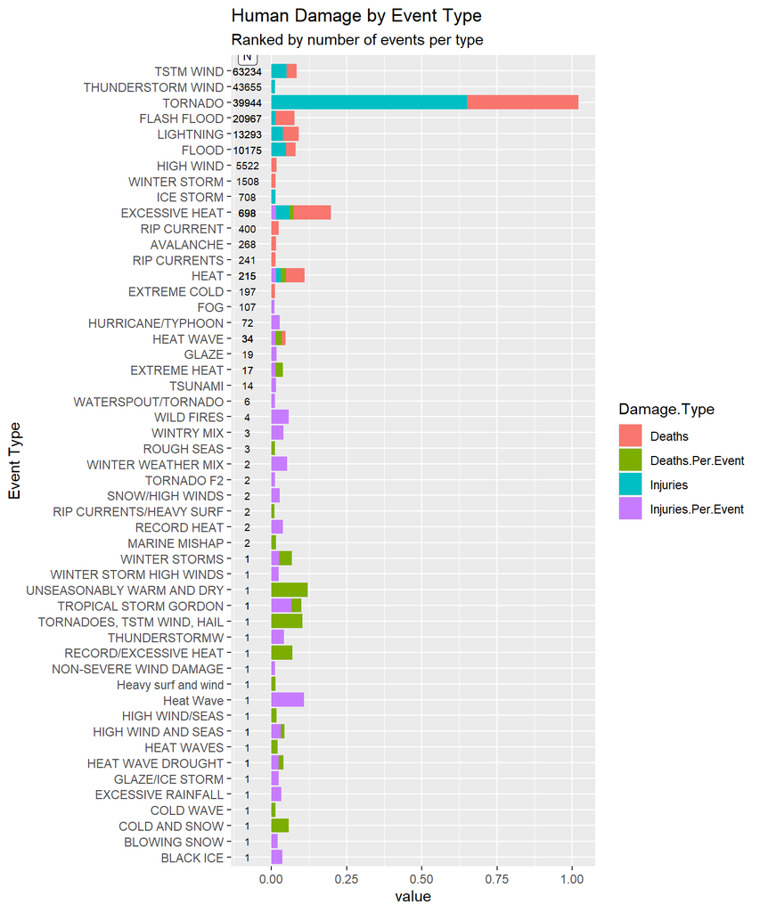

```r
f <- ggplot(longHumanStormData, aes(fill=Damage.Type, x = EVTYPE, y = value))
f+geom_col(position = "stack") +
     geom_text(data=longHumanStormData, aes(label = n, y=-0.08),
          size=2.5)+
     labs(title = "Human Damage by Event Type",
          subtitle = "Ranked by number of events per type",
          x = "Event Type" )+
     annotate("label",x = 52, y = -0.08, label = "N", size = 3)+
     coord_flip()
```

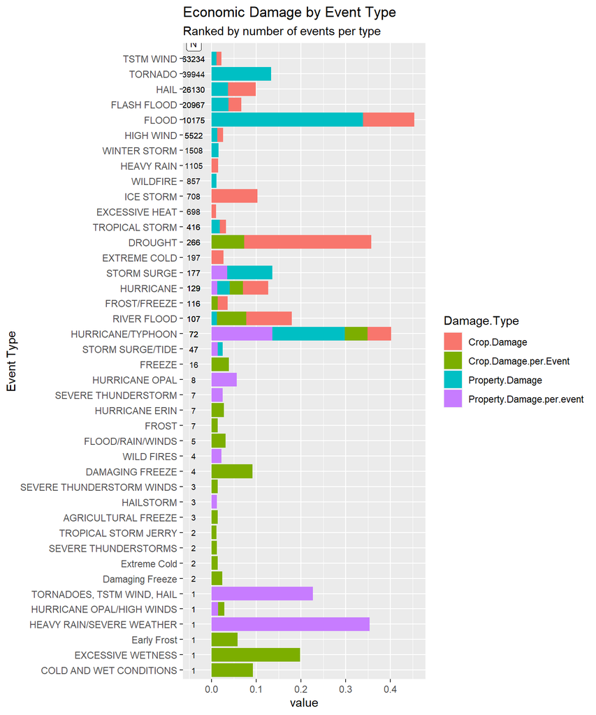

```r
g <- ggplot(longEconStormData, aes(fill=Damage.Type, x = EVTYPE, y = value))
g + geom_col(position = "stack") +
     geom_text(data=longEconStormData, aes(label = n, y=-0.04),
          size=2.5)+
     labs(title = "Economic Damage by Event Type",
           subtitle = "Ranked by number of events per type",
          x = "Event Type" ) +
     annotate("label",x = 42, y = -0.04, label = "N", size = 3)+
     coord_flip()
```

In terms of human damage, tornadoes have the highest impact in both injuries and deaths, whereas one event each which were “UNSEASONABLY WARM AND DRY” and “Heat Wave” had the highest impacts per individual event. In terms of total economic damage, FLOOD has the highest impact on property damage DROUGHT has the highest impact on crop damage. Again one event each had the highest impact on a per-event basis: “HEAVY RAIN/SEVERE WEATHER” on property damage and “EXCESSIVE WETNESS” on crop damage.

It is notable that many of the “Per Event” values are high in events that are representing event types with only one incident. A larger project to properly categorize those into larger event types would likely be useful. For example “Heat Wave”, which is a category with only one event, shows the highest number of injuries per event, but should likely be averaged into the “HEAT” category (which should both likely be averaged into “EXCESSIVE HEAT”, etc.).